# Biostat 203B Homework 2

Due Feb 6 @ 11:59PM

Rozeta Avetisyan

```r
knitr::opts_chunk$set(echo = TRUE, cache = TRUE, cache.lazy = FALSE)
library(tidyverse)
library(data.table)
library(lubridate)
```

```r
os <- sessionInfo()$running
if (str_detect(os, "Linux")) {
  mimic_path <- "/mnt/mimiciv/1.0"
} else if (str_detect(os, "macOS")) {
  mimic_path <- "/Users/huazhou/Documents/Box Sync/MIMIC/mimic-iv-1.0"
}
```

In this exercise, we use tidyverse (ggpot2, dplyr, etc) to explore the [MIMIC-IV](https://mimic.mit.edu/docs/iv/) data introduced in [homework 1](https://ucla-biostat-203b.github.io/2022winter/hw/hw1/hw1.html) and to build a cohort of ICU stays.

```r
# tree -s -L 2 /Users/huazhou/Documents/Box\ Sync/MIMIC/mimic-iv-1.0
system(str_c("tree -s -L 2 ", shQuote(mimic_path)), intern = TRUE)
```

```
##  [1] "/mnt/mimiciv/1.0"
##  [2] "├── [       4096]  core"
##  [3] "│   ├── [   17208966]  admissions.csv.gz"
##  [4] "│   ├── [        606]  index.html"
##  [5] "│   ├── [    2955582]  patients.csv.gz"
##  [6] "│   └── [   53014503]  transfers.csv.gz"
##  [7] "├── [       4096]  hosp"
##  [8] "│   ├── [     430049]  d_hcpcs.csv.gz"
##  [9] "│   ├── [   29531152]  diagnoses_icd.csv.gz"
## [10] "│   ├── [     863239]  d_icd_diagnoses.csv.gz"
## [11] "│   ├── [     579998]  d_icd_procedures.csv.gz"
## [12] "│   ├── [      14898]  d_labitems.csv.gz"
## [13] "│   ├── [   11684062]  drgcodes.csv.gz"
## [14] "│   ├── [  515763427]  emar.csv.gz"
## [15] "│   ├── [  476252563]  emar_detail.csv.gz"
```

[output cut: 26 more lines]

## Q1. `read.csv` (base R) vs `read_csv` (tidyverse) vs `fread` (data.table)

There are quite a few utilities in R for reading plain text data files. Let us test the speed of reading a moderate sized compressed csv file, `admissions.csv.gz`, by three programs: `read.csv` in base R, `read_csv` in tidyverse, and `fread` in the popular data.table package.

Which function is fastest? Is there difference in the (default) parsed data types? (Hint: R function `system.time` measures run times.)

For later questions, we stick to the tidyverse.

```r
#Tibble to store the read times in:
read_times <- tibble(
  ST_baseR = 1:3,
  ET_baseR = 0,
  ST_tidyR = 0,
  ET_tidyR = 0,
  ST_fread = 0,
  ET_fread = 0,
  RT_tidy = 0,
  RT_baseR = 0,
  RT_fread = 0
)

#storing read times into appropriate columns of the tibble from above:
for(i in 1:nrow(read_times)){
  read_times$ST_baseR[i] <- Sys.time()
  admissions_baseR <- read.csv("/mnt/mimiciv/1.0/core/admissions.csv.gz")
  read_times$ET_baseR[i] <- Sys.time()
  read_times$RT_baseR[i] = read_times$ET_baseR[i] - read_times$ST_baseR[i]
  read_times$ST_tidyR[i] <- Sys.time()
  admissions_tidyR <- read_csv("/mnt/mimiciv/1.0/core/admissions.csv.gz")
  read_times$ET_tidyR[i] <- Sys.time()
  read_times$RT_tidy[i] = read_times$ET_tidyR[i] - read_times$ST_tidyR[i]
  read_times$ST_fread[i] <- Sys.time()
  admissions_fread <- read_csv("/mnt/mimiciv/1.0/core/admissions.csv.gz")
  read_times$ET_fread[i] <- Sys.time()
  read_times$RT_fread[i] = read_times$ET_fread[i] - read_times$ST_fread[i]
}
# #getting information about the data types:
# str(admissions_baseR)
# str(admissions_tidyR)
# str(admissions_fread)
```

[output not shown]

## Q2. ICU stays

`icustays.csv.gz` (https://mimic.mit.edu/docs/iv/modules/icu/icustays/) contains data about Intensive Care Units (ICU) stays. The first 10 lines are

```r
system(
  str_c(
    "zcat < ",
    shQuote(str_c(mimic_path, "/icu/icustays.csv.gz")),
    " | head"
    ),
  intern = TRUE
)
```

```
##  [1] "subject_id,hadm_id,stay_id,first_careunit,last_careunit,intime,outtime,los"
##  [2] "17867402,24528534,31793211,Trauma SICU (TSICU),Trauma SICU (TSICU),2154-03-03 04:11:00,2154-03-04 18:16:56,1.5874537037037035"
##  [3] "14435996,28960964,31983544,Trauma SICU (TSICU),Trauma SICU (TSICU),2150-06-19 17:57:00,2150-06-22 18:33:54,3.025625"
##  [4] "17609946,27385897,33183475,Trauma SICU (TSICU),Trauma SICU (TSICU),2138-02-05 18:54:00,2138-02-15 12:42:05,9.741724537037038"
##  [5] "18966770,23483021,34131444,Trauma SICU (TSICU),Trauma SICU (TSICU),2123-10-25 10:35:00,2123-10-25 18:59:47,0.35054398148148147"
##  [6] "12776735,20817525,34547665,Neuro Stepdown,Neuro Stepdown,2200-07-12 00:33:00,2200-07-13 16:44:40,1.6747685185185184"
##  [7] "10215159,24283593,34569476,Trauma SICU (TSICU),Trauma SICU (TSICU),2124-09-20 15:05:29,2124-09-21 22:06:58,1.2926967592592593"
##  [8] "14489052,26516390,35056286,Trauma SICU (TSICU),Trauma SICU (TSICU),2118-10-26 10:33:56,2118-10-26 20:28:10,0.4126620370370371"
##  [9] "15914763,28906020,36909804,Trauma SICU (TSICU),Trauma SICU (TSICU),2176-12-14 12:00:00,2176-12-17 11:47:01,2.9909837962962964"
## [10] "16256226,20013290,39289362,Neuro Stepdown,Neuro Stepdown,2150-12-20 16:09:08,2150-12-21 14:58:40,0.9510648148148149"
```

1. Import `icustatys.csv.gz` as a tibble `icustays_tble`.

```r
#reading in the data set
icustays_tble <- read_csv("/mnt/mimiciv/1.0/icu/icustays.csv.gz")
#converting it to a tibble
icustays_tble <- as_tibble(icustays_tble)
```

2. How many unique `subject_id`? Can a `subject_id` have multiple ICU stays?

```r
#reading in the data set
unique_ID <- icustays_tble %>%
    n_distinct(.$subject_id)
```

3. For each `subject_id`, let’s only keep the first ICU stay in the tibble `icustays_tble`.

```r
rm(unique_ID)
#To keep only 1st stay: 1) sorted in ascending order, 2) kept 1st stays per ID
icustays_tble <- icustays_tble %>%
    arrange(intime) %>%
    distinct(subject_id, .keep_all = T)
```

## Q3. `admission` data

Information of the patients admitted into hospital is available in `admissions.csv.gz`. See https://mimic.mit.edu/docs/iv/modules/core/admissions/ for details of each field in this file. The first 10 lines are

```r
system(
  str_c(
    "zcat < ",
    shQuote(str_c(mimic_path, "/core/admissions.csv.gz")),
    " | head"
    ),
  intern = TRUE
)
```

```
##  [1] "subject_id,hadm_id,admittime,dischtime,deathtime,admission_type,admission_location,discharge_location,insurance,language,marital_status,ethnicity,edregtime,edouttime,hospital_expire_flag"
##  [2] "14679932,21038362,2139-09-26 14:16:00,2139-09-28 11:30:00,,ELECTIVE,,HOME,Other,ENGLISH,SINGLE,UNKNOWN,,,0"
##  [3] "15585972,24941086,2123-10-07 23:56:00,2123-10-12 11:22:00,,ELECTIVE,,HOME,Other,ENGLISH,,WHITE,,,0"
##  [4] "11989120,21965160,2147-01-14 09:00:00,2147-01-17 14:25:00,,ELECTIVE,,HOME,Other,ENGLISH,,UNKNOWN,,,0"
##  [5] "17817079,24709883,2165-12-27 17:33:00,2165-12-31 21:18:00,,ELECTIVE,,HOME,Other,ENGLISH,,OTHER,,,0"
##  [6] "15078341,23272159,2122-08-28 08:48:00,2122-08-30 12:32:00,,ELECTIVE,,HOME,Other,ENGLISH,,BLACK/AFRICAN AMERICAN,,,0"
##  [7] "19124609,20517215,2169-03-14 12:44:00,2169-03-20 19:15:00,,ELECTIVE,,HOME,Other,ENGLISH,,UNKNOWN,,,0"
##  [8] "17301855,29732723,2140-06-06 14:23:00,2140-06-08 14:25:00,,ELECTIVE,,HOME,Other,ENGLISH,,WHITE,,,0"
##  [9] "17991012,24298836,2181-07-10 20:28:00,2181-07-12 15:49:00,,ELECTIVE,,HOME,Other,ENGLISH,,WHITE,,,0"
## [10] "16865435,23216961,2185-07-19 02:12:00,2185-07-21 11:50:00,,ELECTIVE,,HOME,Other,ENGLISH,,WHITE,,,0"
```

1. Import `admissions.csv.gz` as a tibble `admissions_tble`.

```r
admissions_tble <- as_tibble(admissions_tidyR)
rm(admissions_tidyR)
```

2. Let’s only keep the admissions that have a match in `icustays_tble` according to `subject_id` and `hadm_id`.

```r
join_keys <- c("subject_id", "hadm_id")
admissions_tble <- admissions_tble %>%
    inner_join(y = icustays_tble, by = join_keys)
#check if there are duplicate columns to remove:
admissions_tble <- admissions_tble[!duplicated(as.list(admissions_tble))]
rm(join_keys)
```

3. Summarize the following variables by graphics.
- admission year

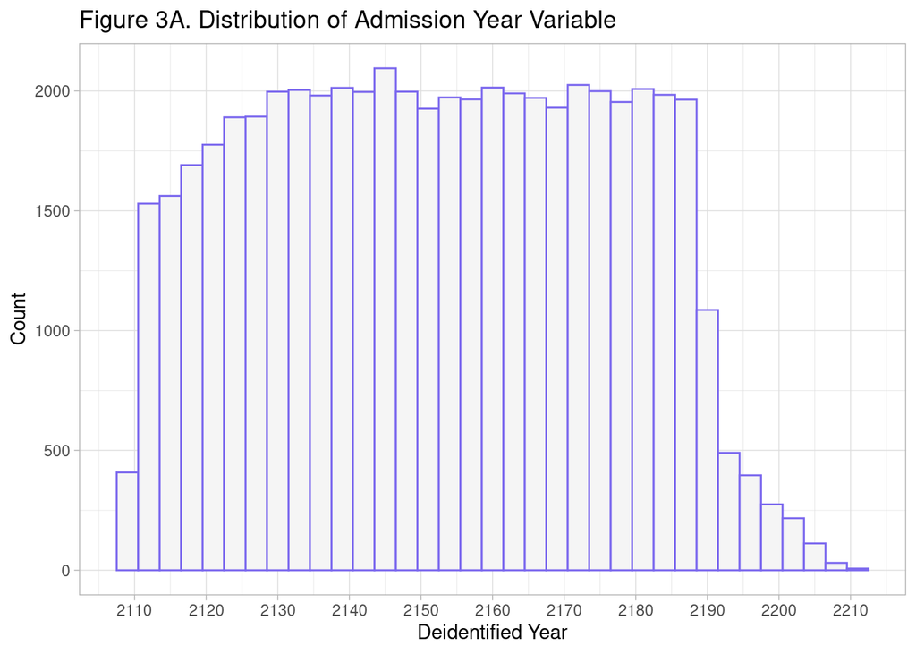

```r
# admission_year <- year(admissions_tble$admittime)
data_collection_start <-  min(year(icustays_tble$intime))
data_collection_end <-  max(year(icustays_tble$intime))

library(ggplot2)

admissions_tble %>%
  mutate(admission_year = year(admissions_tble$admittime)) %>%
  ggplot(aes(admission_year)) +
  geom_histogram(binwidth = 3, color = "mediumslateblue", fill = "grey96") +
  scale_x_continuous(breaks = pretty(year(admissions_tble$admittime), n = 10)) +
  ggtitle("Figure 3A. Distribution of Admission Year Variable") +
  xlab("Deidentified Year") +
  ylab("Count") +
  theme_light()
```

The initial look at admission year variable using a histogram suggested that this variable must be incorrectly formatted. Based on MIMIC IV description, data were collected 2008-2019. Yet, year variable in the tables range from 2110 to 2211. However, additional investigation revealed that this formatting is a de-identification of the year variable to limit the information to a 3-year window which may be revealed later when analyzing the `patients` data set.

- admission month

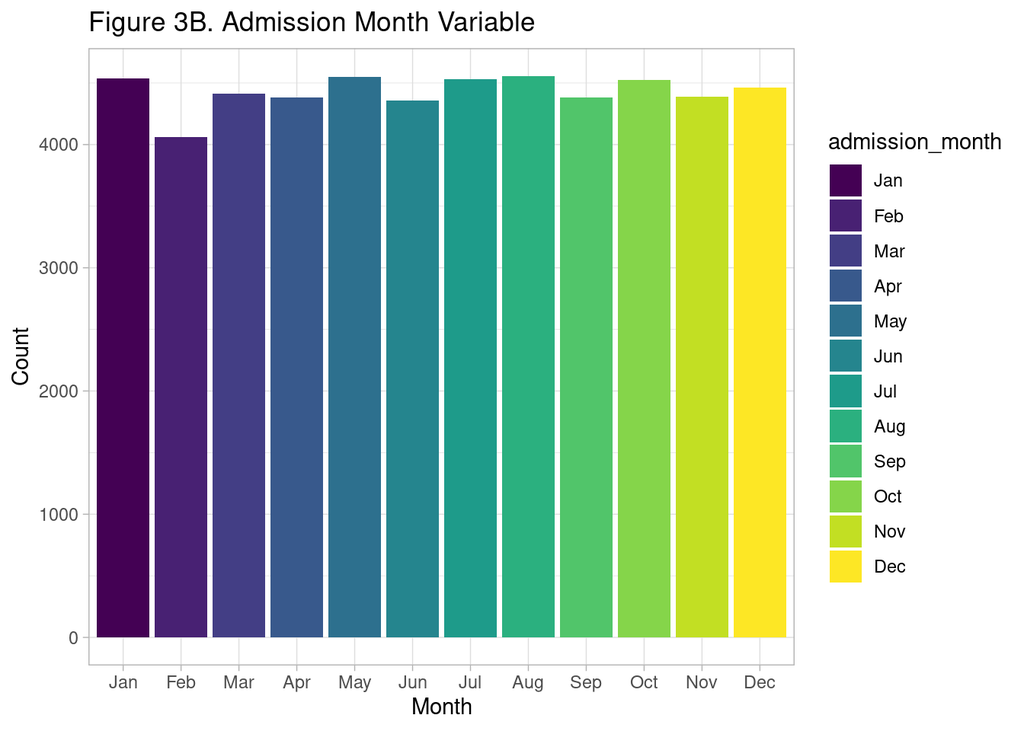

```r
#removing variables not necessary anymore
rm(data_collection_start)
rm(data_collection_end)

admissions_tble %>%
  mutate(admission_month = month(admissions_tble$admittime, label = T)) %>%
  ggplot(aes(admission_month, fill = admission_month)) +
  geom_bar() +
  ggtitle("Figure 3B. Admission Month Variable") +
  xlab("Month") +
  ylab("Count") +
  theme_light()
```

- admission month day

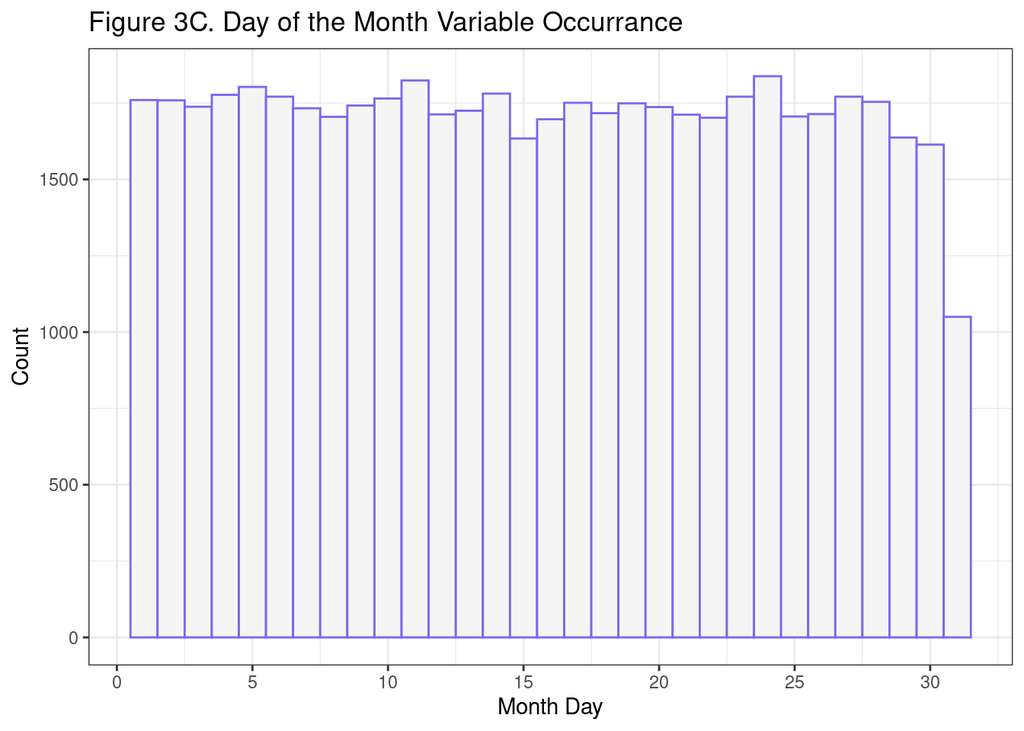

```r
admissions_tble %>%
  mutate(month_day = mday(admissions_tble$admittime)) %>%
  ggplot(aes(month_day)) +
  geom_histogram(binwidth = 1, color = "mediumslateblue", fill = "grey96") +
  scale_x_continuous(breaks = pretty(mday(admissions_tble$admittime), n = 10)) +
  ggtitle("Figure 3C. Day of the Month Variable Occurrance") +
  xlab("Month Day") +
  ylab("Count") +
  theme_bw()
```

- admission week day

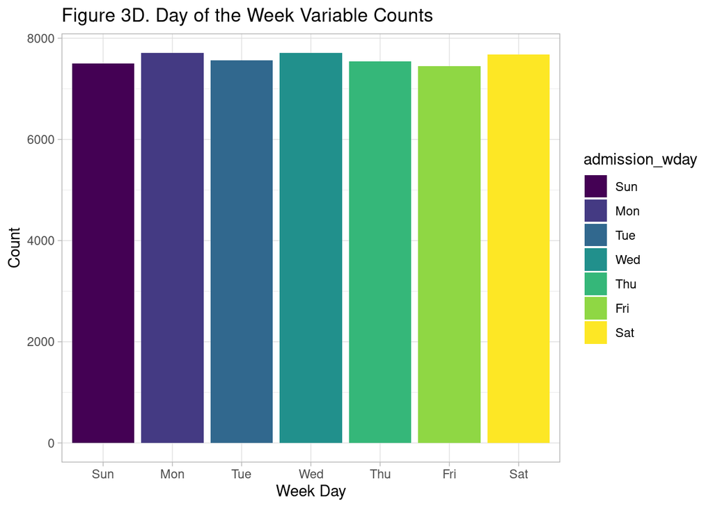

```r
admissions_tble %>%
  mutate(admission_wday = wday(admissions_tble$admittime, label = T)) %>%
  ggplot(aes(admission_wday, fill = admission_wday)) +
  geom_bar() +
  ggtitle("Figure 3D. Day of the Week Variable Counts") +
  labs( x = "Week Day", y = "Count", color = "Week Day") +
  theme_light()
```

- admission hour (anything unusual?)

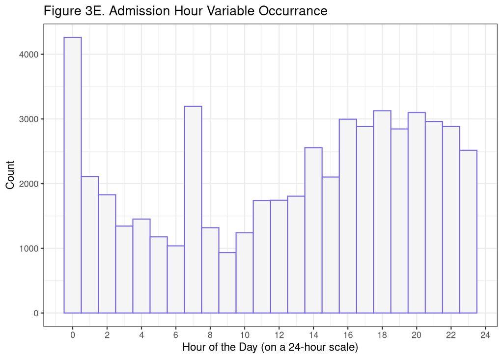

```r
admissions_tble %>%
  mutate(admit_hour = hour(admissions_tble$admittime)) %>%
  ggplot(aes(admit_hour)) +
  geom_histogram(binwidth = 1, color = "mediumslateblue", fill = "grey96") +
  scale_x_continuous(breaks = pretty(hour(admissions_tble$admittime), n = 12)) +
  ggtitle("Figure 3E. Admission Hour Variable Occurrance") +
  xlab("Hour of the Day (on a 24-hour scale)") +
  ylab("Count") +
  theme_bw()
```

Based on *Figure 3E* above, there seem to be high number of admissions at hour 0, which would denote midnight. Additionally, there are also large number of admissions at 7am. Using my limited domain knowledge in hospital shift scheduling, I assume these seemingly increased admissions are actually a result of shift change. At 7am new shift begins, thus, admissions staff who start their day at 7am may be entering the data for patients admitted during the previous night if the staff before them got too busy with other tasks.

## Q4. `patients` data

Patient information is available in `patients.csv.gz`. See https://mimic.mit.edu/docs/iv/modules/core/patients/ for details of each field in this file. The first 10 lines are

```r
system(
  str_c(
    "zcat < ",
    shQuote(str_c(mimic_path, "/core/patients.csv.gz")),
    " | head"
    ),
  intern = TRUE
)
```

```
##  [1] "subject_id,gender,anchor_age,anchor_year,anchor_year_group,dod"
##  [2] "10000048,F,23,2126,2008 - 2010,"
##  [3] "10002723,F,0,2128,2017 - 2019,"
##  [4] "10003939,M,0,2184,2008 - 2010,"
##  [5] "10004222,M,0,2161,2014 - 2016,"
##  [6] "10005325,F,0,2154,2011 - 2013,"
##  [7] "10007338,F,0,2153,2017 - 2019,"
##  [8] "10008101,M,0,2142,2008 - 2010,"
##  [9] "10009872,F,0,2168,2014 - 2016,"
## [10] "10011333,F,0,2132,2014 - 2016,"
```

1. Import `patients.csv.gz` (https://mimic.mit.edu/docs/iv/modules/core/patients/) as a tibble `patients_tble` and only keep the patients who have a match in `icustays_tble` (according to `subject_id`).

```r
patients_tble <- read_csv("/mnt/mimiciv/1.0/core/patients.csv.gz")
patients_tble <- tibble( patients_tble)
patients_tble <- inner_join(patients_tble, icustays_tble, by = c("subject_id"))
```

2. Summarize variables `gender` and `anchor_age`, and explain any patterns you see.

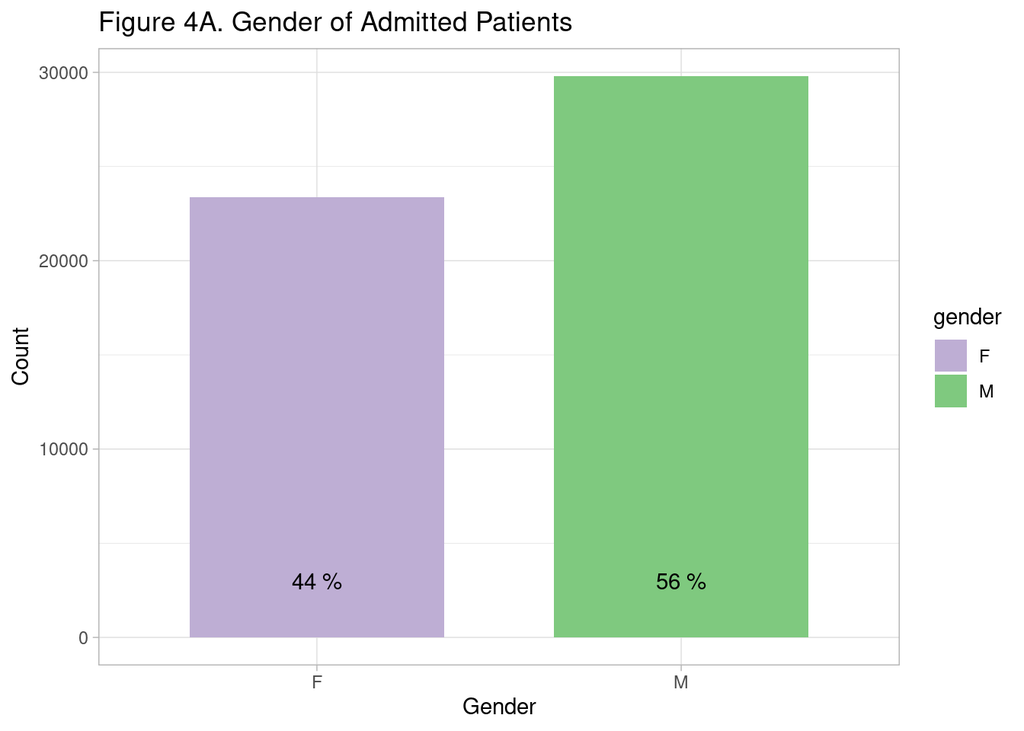

```r
pct <- patients_tble %>%
              group_by(gender) %>%
              summarise(pct = format(100*n()/nrow(patients_tble), digits = 2))

patients_tble %>%
  ggplot(aes(x = gender, fill = gender)) +
  geom_bar(width = 0.7) +
  scale_fill_brewer(palette = "Accent", direction = -1) +
  ggtitle("Figure 4A. Gender of Admitted Patients") +
  annotate("text", x = "F", y = 3000, label = paste(pct[1,2],"%")) +
  annotate("text", x = "M", y = 3000, label = paste(pct[2,2],"%")) +
  xlab("Gender") +
  ylab("Count") +
  theme(aspect.ratio=1/2) +
  theme_light()
```

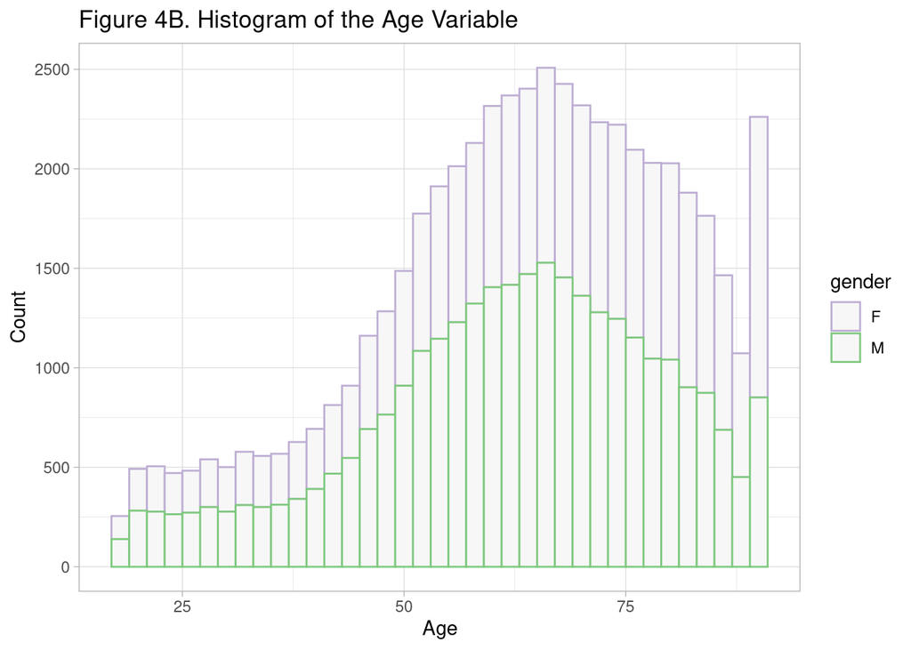

```r
patients_tble %>%
  ggplot(aes(x = anchor_age, color = gender)) +
  geom_histogram(binwidth = 2, fill = "grey97") +
  scale_color_brewer(palette = "Accent", direction = -1) +
  ggtitle("Figure 4B. Histogram of the Age Variable") +
  xlab("Age") +
  ylab("Count") +
  theme_light()
```

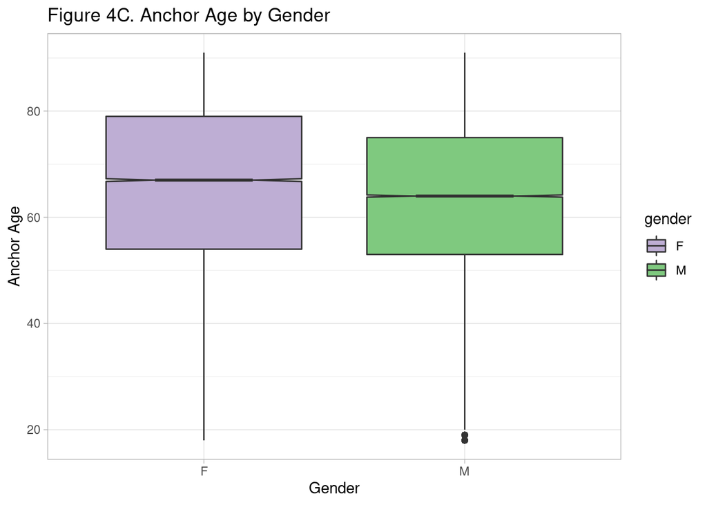

```r
patients_tble %>%
  group_by(gender) %>%
  ggplot(aes(x = gender, y = anchor_age, fill = gender)) +
  geom_boxplot(notch = T) +
  scale_fill_brewer(palette = "Accent", direction = -1) +
  ggtitle("Figure 4C. Anchor Age by Gender") +
  xlab("Gender") +
  ylab("Anchor Age") +
  theme_light()
```

```r
rm(pct)
```

## Q5. Lab results

`labevents.csv.gz` (https://mimic.mit.edu/docs/iv/modules/hosp/labevents/) contains all laboratory measurements for patients. The first 10 lines are

```r
system(
  str_c(
    "zcat < ",
    shQuote(str_c(mimic_path, "/hosp/labevents.csv.gz")),
    " | head"
    ),
  intern = TRUE
)
```

```
##  [1] "labevent_id,subject_id,hadm_id,specimen_id,itemid,charttime,storetime,value,valuenum,valueuom,ref_range_lower,ref_range_upper,flag,priority,comments"
##  [2] "670,10000048,,6448755,51484,2126-11-22 19:20:00,2126-11-22 20:07:00,150,150,mg/dL,,,,STAT,"
##  [3] "673,10000048,,6448755,51491,2126-11-22 19:20:00,2126-11-22 20:07:00,6.5,6.5,units,5,8,,STAT,"
##  [4] "675,10000048,,6448755,51498,2126-11-22 19:20:00,2126-11-22 20:07:00,1.029,1.029, ,1.001,1.035,,STAT,"
##  [5] "683,10000048,,82729055,50861,2126-11-22 20:45:00,2126-11-23 00:55:00,39,39,IU/L,0,40,,STAT,"
##  [6] "684,10000048,,82729055,50862,2126-11-22 20:45:00,2126-11-23 00:55:00,4.7,4.7,g/dL,3.4,4.8,,STAT,"
##  [7] "685,10000048,,82729055,50863,2126-11-22 20:45:00,2126-11-23 00:55:00,45,45,IU/L,39,117,,STAT,"
##  [8] "686,10000048,,82729055,50868,2126-11-22 20:45:00,2126-11-22 21:32:00,13,13,mEq/L,8,20,,STAT,"
##  [9] "687,10000048,,82729055,50878,2126-11-22 20:45:00,2126-11-23 00:55:00,28,28,IU/L,0,40,,STAT,"
## [10] "688,10000048,,82729055,50882,2126-11-22 20:45:00,2126-11-22 21:32:00,26,26,mEq/L,22,32,,STAT,"
```

`d_labitems.csv.gz` is the dictionary of lab measurements.

```r
system(
  str_c(
    "zcat < ",
    shQuote(str_c(mimic_path, "/hosp/d_labitems.csv.gz")),
    " | head"
    ),
  intern = TRUE
)
```

```
##  [1] "itemid,label,fluid,category,loinc_code"
##  [2] "51905, ,Other Body Fluid,Chemistry,"
##  [3] "51532,11-Deoxycorticosterone,Blood,Chemistry,"
##  [4] "51957,17-Hydroxycorticosteroids,Urine,Chemistry,"
##  [5] "51958,\"17-Ketosteroids, Urine\",Urine,Chemistry,"
##  [6] "52068,24 Hr,Blood,Hematology,"
##  [7] "51066,24 hr Calcium,Urine,Chemistry,"
##  [8] "51067,24 hr Creatinine,Urine,Chemistry,"
##  [9] "51068,24 hr Protein,Urine,Chemistry,"
## [10] "50853,25-OH Vitamin D,Blood,Chemistry,"
```

1. Find how many rows are in `labevents.csv.gz`.

```r
read_csv(
        "/mnt/mimiciv/1.0/hosp/labevents.csv.gz",
        col_select = 1,
        lazy = T
        ) %>%
  nrow()
```

```
## [1] 122103667
```

2. We are interested in the lab measurements of creatinine (50912), potassium (50971), sodium (50983), chloride (50902), bicarbonate (50882), hematocrit (51221), white blood cell count (51301), glucose (50931), magnesium (50960), and calcium (50893). Retrieve a subset of `labevents.csv.gz` only containing these items for the patients in `icustays_tble` as a tibble `labevents_tble`.

   Hint: `labevents.csv.gz` is a data file too big to be read in by the `read_csv` function in its default setting. Utilize the `col_select` and `lazy` options in the `read_csv` function to reduce the memory burden.

```r
labs_of_interest <- c("50912", "50971", "50983", "50902", "50882",
                      "51221", "51301", "50931", "50960", "50893")

labitems_tble <- read_csv(
                           "/mnt/mimiciv/1.0/hosp/d_labitems.csv.gz",
                           col_select = c(1, 2),
                           lazy = T
                          )  %>%
                   filter(itemid %in% labs_of_interest)
#reading in the data set
labevents_tble <- read_csv(
    "/mnt/mimiciv/1.0/hosp/labevents_filtered_itemid.csv.gz") %>%
      inner_join(y = labitems_tble, by = "itemid") %>%
      inner_join(y = icustays_tble, by = "subject_id") %>%
      select(-los)
rm(labitems_tble)
rm(labs_of_interest)
```

3. Further restrict `labevents_tble` to the first lab measurement during the ICU stay.

```r
labevents_tble <- labevents_tble %>%
   group_by(subject_id) %>%
   arrange(charttime, .group_by = T) %>%
   slice_head(n = 1) %>%
   ungroup()
```

4. Summarize the lab measurements by appropriate numerics and graphics.

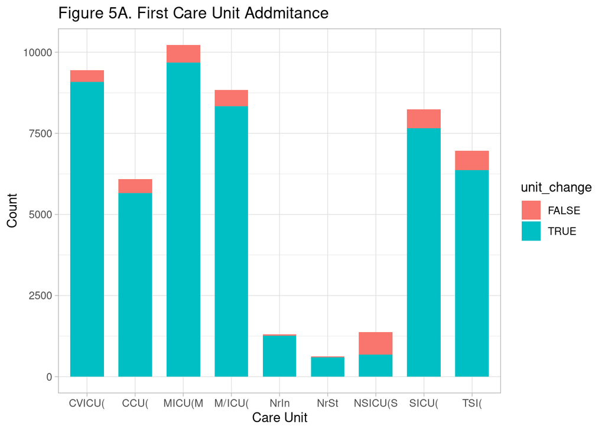

```r
lab_tests<-c("bicarbonate", "calcium", "chloride", "creatinine", "glucose",
    "hematocrit", "magnesium", "potassium", "sodium", "white blood cell count")
test_abbrev <-c("Bicarb",  "Calc", "Chlor", "Crt", "Gluc", "Hmt",  "Mag",
     "Potas", "Sod", "WBC_Count")

vars_have <- colnames(labevents_tble)
labevents_tble %>%
  mutate(unit_change = (first_careunit == last_careunit)) %>%
  ggplot(aes(x = first_careunit, fill = unit_change)) +
  geom_bar(position = "stack", width = 0.7) +
  scale_x_discrete(labels = abbreviate) +
  ggtitle("Figure 5A. First Care Unit Addmitance") +
  xlab("Care Unit") +
  ylab("Count") +
  theme(aspect.ratio = 1/2) +
  theme_light()
```

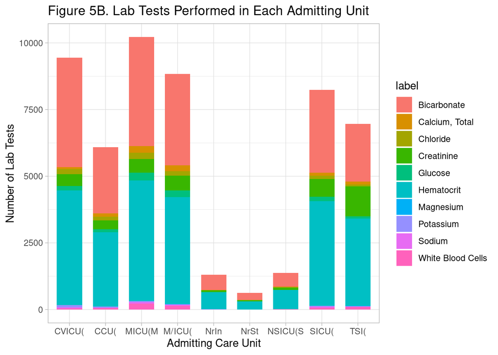

```r
labevents_tble %>%
  ggplot(aes(x = first_careunit, fill = label)) +
  geom_bar(position = "stack", width = 0.7) +
  scale_x_discrete(labels = abbreviate) +
  ggtitle("Figure 5B. Lab Tests Performed in Each Admitting Unit ") +
  xlab("Admitting Care Unit") +
  ylab("Number of Lab Tests") +
  theme_light()
```

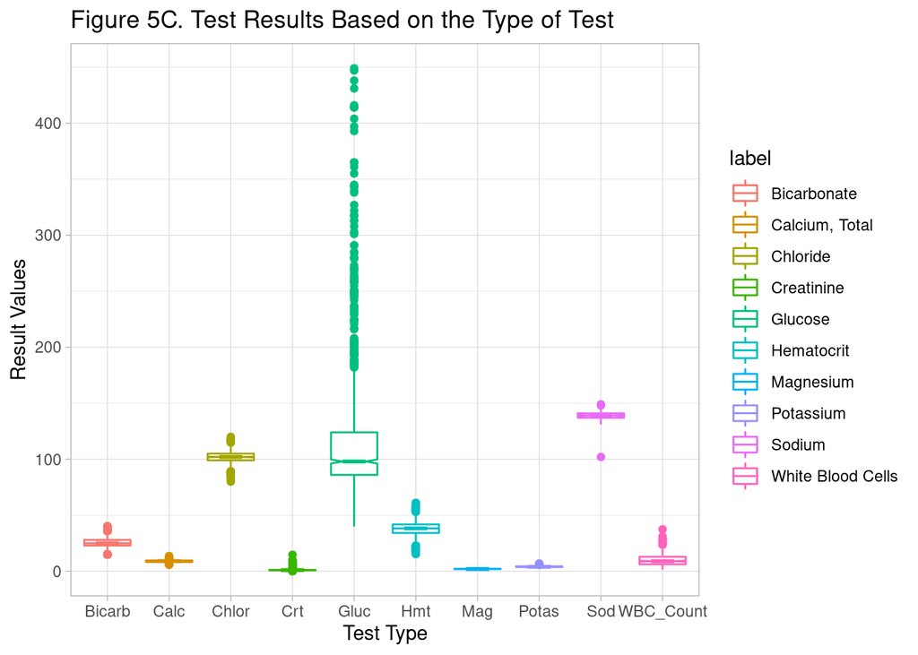

```r
labevents_tble %>%
  ggplot(aes(x = label, y = valuenum, color = label)) +
  geom_boxplot(notch = T) +
  scale_x_discrete(labels = test_abbrev) +
  ggtitle("Figure 5C. Test Results Based on the Type of Test") +
  xlab("Test Type") +
  ylab("Result Values") +
  theme_light()
```

```r
labevents_tble %>%
  select(subject_id, itemid, valuenum, first_careunit, last_careunit) %>%
  pivot_wider(names_from = itemid, values_from = valuenum) %>%
  summarize(
    count = n(),
    bicarbonate = format(mean(na.omit(`50882`)), digits = 3),
    calcium = format(mean(na.omit(`50893`)), digits = 3),
    chloride = format(mean(na.omit(`50902`)), digits = 3),
    creatinine = format(mean(na.omit(`50912`)), digits = 3),
    glucose = format(mean(na.omit(`50931`)), digits = 3),
    hematocrit = format(mean(na.omit(`51221`)), digits = 3),
    magnesium = format(mean(na.omit(`50960`)), digits = 3),
    potassium = format(mean(na.omit(`50971`)), digits = 3),
    sodium = format(mean(na.omit(`50983`)), digits = 3),
    WBC_count = format(mean(na.omit(`51301`)), digits = 3)
  )
```

```
## # A tibble: 1 × 11
##   count bicarbonate calcium chloride creatinine glucose hematocrit magnesium
##   <int> <chr>       <chr>   <chr>    <chr>      <chr>   <chr>      <chr>
## 1 53097 25          8.84    102      1.1        118     38         2.01
## # … with 3 more variables: potassium <chr>, sodium <chr>, WBC_count <chr>
```

```r
rm(test_abbrev)
#rm(labevents_tble)
```

## Q6. Vitals from charted events

`chartevents.csv.gz` (https://mimic.mit.edu/docs/iv/modules/icu/chartevents/) contains all the charted data available for a patient. During their ICU stay, the primary repository of a patient’s information is their electronic chart. The `itemid` variable indicates a single measurement type in the database. The `value` variable is the value measured for `itemid`. The first 10 lines of `chartevents.csv.gz` are

```r
system(
  str_c(
    "zcat < ",
    shQuote(str_c(mimic_path, "/icu/chartevents.csv.gz")),
    " | head"),
  intern = TRUE
)
```

```
##  [1] "subject_id,hadm_id,stay_id,charttime,storetime,itemid,value,valuenum,valueuom,warning"
##  [2] "10003700,28623837,30600691,2165-04-24 05:10:00,2165-04-24 05:11:00,228236,0,0,,0"
##  [3] "10003700,28623837,30600691,2165-04-24 05:12:00,2165-04-24 05:14:00,225067,0,0,,0"
##  [4] "10003700,28623837,30600691,2165-04-24 05:12:00,2165-04-24 05:14:00,225070,1,1,,0"
##  [5] "10003700,28623837,30600691,2165-04-24 05:12:00,2165-04-24 05:14:00,225076,1,1,,0"
##  [6] "10003700,28623837,30600691,2165-04-24 05:12:00,2165-04-24 05:14:00,225078,1,1,,0"
##  [7] "10003700,28623837,30600691,2165-04-24 05:12:00,2165-04-24 05:14:00,225086,1,1,,0"
##  [8] "10003700,28623837,30600691,2165-04-24 05:12:00,2165-04-24 05:14:00,225091,1,1,,0"
##  [9] "10003700,28623837,30600691,2165-04-24 05:12:00,2165-04-24 05:14:00,225103,1,1,,0"
## [10] "10003700,28623837,30600691,2165-04-24 05:12:00,2165-04-24 05:14:00,225106,1,1,,0"
```

`d_items.csv.gz` (https://mimic.mit.edu/docs/iv/modules/icu/d_items/) is the dictionary for the `itemid` in `chartevents.csv.gz`.

```r
system(
  str_c(
    "zcat < ",
    shQuote(str_c(mimic_path, "/icu/d_items.csv.gz")),
    " | head"),
  intern = TRUE
)
```

```
##  [1] "itemid,label,abbreviation,linksto,category,unitname,param_type,lownormalvalue,highnormalvalue"
##  [2] "220003,ICU Admission date,ICU Admission date,datetimeevents,ADT,,Date and time,,"
##  [3] "220045,Heart Rate,HR,chartevents,Routine Vital Signs,bpm,Numeric,,"
##  [4] "220046,Heart rate Alarm - High,HR Alarm - High,chartevents,Alarms,bpm,Numeric,,"
##  [5] "220047,Heart Rate Alarm - Low,HR Alarm - Low,chartevents,Alarms,bpm,Numeric,,"
##  [6] "220048,Heart Rhythm,Heart Rhythm,chartevents,Routine Vital Signs,,Text,,"
##  [7] "220050,Arterial Blood Pressure systolic,ABPs,chartevents,Routine Vital Signs,mmHg,Numeric,90,140"
##  [8] "220051,Arterial Blood Pressure diastolic,ABPd,chartevents,Routine Vital Signs,mmHg,Numeric,60,90"
##  [9] "220052,Arterial Blood Pressure mean,ABPm,chartevents,Routine Vital Signs,mmHg,Numeric,,"
## [10] "220056,Arterial Blood Pressure Alarm - Low,ABP Alarm - Low,chartevents,Alarms,mmHg,Numeric,,"
```

1. We are interested in the vitals for ICU patients: heart rate (220045), mean non-invasive blood pressure (220181), systolic non-invasive blood pressure (220179), body temperature in Fahrenheit (223761), and respiratory rate (220210). Retrieve a subset of `chartevents.csv.gz` only containing these items for the patients in `icustays_tble` as a tibble `chartevents_tble`.

```r
vitals_of_interest <- c("220045", "220181", "220179", "223761", "220210")

vitals_items <- read_csv("/mnt/mimiciv/1.0/icu/d_items.csv.gz",
  col_select = c(1, 2, 3, 5, 6)) %>%
                 filter(itemid %in% vitals_of_interest)
```

```r
#reading in the data set
chartevents_tble <- read_csv(
  "/mnt/mimiciv/1.0/icu/chartevents_filtered_itemid.csv.gz") %>%
  inner_join(y = vitals_items, by = "itemid") %>%
  inner_join(y = icustays_tble, by = c("subject_id", "hadm_id", "stay_id"))
rm(vitals_items)
rm(vitals_of_interest)
```

2. Further restrict `chartevents_tble` to the first vital measurement during the ICU stay.

```r
chartevents_tble <- chartevents_tble %>%
                      group_by(subject_id) %>%
                      arrange(charttime, .group_by = T) %>%
                      slice_head(n = 1) %>%
                      ungroup()
```

3. Summarize these vital measurements by appropriate numerics and graphics.

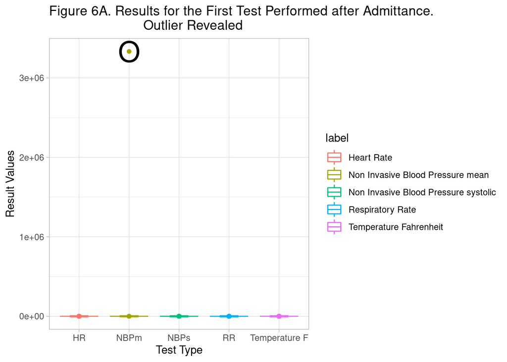

```r
outlier1 <- max(chartevents_tble$valuenum[
  which(chartevents_tble$abbreviation == "NBPm")])

chartevents_tble %>%
  ggplot(aes(x = abbreviation, y = valuenum, color = label)) +
  geom_boxplot(notch = T) +
  ggtitle("Figure 6A. Results for the First Test Performed after Admittance.
                         Outlier Revealed") +
  annotate("text", x = "NBPm", y = outlier1, label ="O", size = 10) +
  xlab("Test Type") +
  ylab("Result Values") +
  theme_light()
```

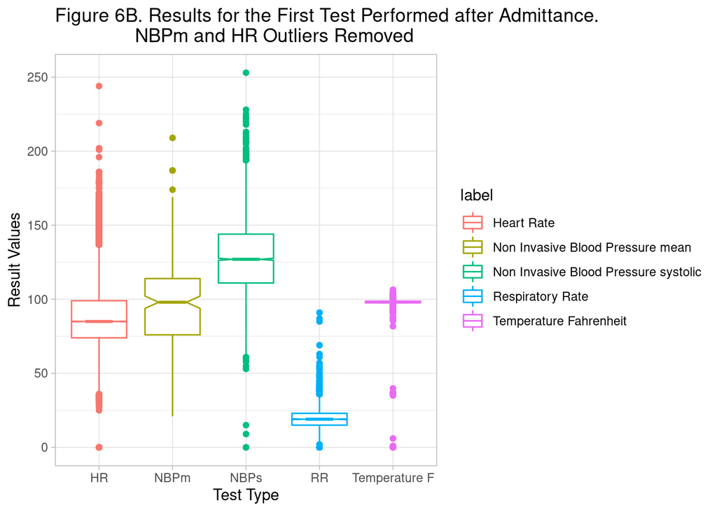

```r
chartevents_tble <- chartevents_tble %>%
  filter(valuenum != outlier1)

#This code revealed an outler in HR but is not necessary for final graphs
# chartevents_tble %>%
#   ggplot(aes(x = abbreviation, y = valuenum, color = label)) +
#   geom_boxplot(notch = T) +
#   ggtitle(
#     "Figure 6B. Results for the First Test Performed after Admittance.
#      NBPm Outlier Removed") +
#   xlab("Test Type") +
#   ylab("Result Values") +
#   theme_light()

outlier2 <- max(chartevents_tble$valuenum[
  which(chartevents_tble$abbreviation == "HR")])

chartevents_tble <- chartevents_tble %>%
  filter(valuenum != outlier2)

chartevents_tble %>%
  ggplot(aes(x = abbreviation, y = valuenum, color = label)) +
  geom_boxplot(notch = T) +
  ggtitle(
    "Figure 6B. Results for the First Test Performed after Admittance.
               NBPm and HR Outliers Removed") +
  xlab("Test Type") +
  ylab("Result Values") +
  theme_light()
```

```r
chartevents_tble %>%
  select(subject_id, itemid, valuenum) %>%
  pivot_wider(names_from = itemid, values_from = valuenum) %>%
  summarize(
    count = n(),
    heart_rate = format(mean(na.omit(`220045`)), digits = 3),
    mean_blood_pressure = format(mean(na.omit(`220181`)), digits = 3),
    blood_pressure_systolic = format(mean(na.omit(`220179`)), digits = 3),
    temperature = format(mean(na.omit(`223761`)), digits = 3),
    respiratory_rate = format(mean(na.omit(`220210`)), digits = 3)
  )
```

```
## # A tibble: 1 × 6
##   count heart_rate mean_blood_pressure blood_pressure_systolic temperature
##   <int> <chr>      <chr>               <chr>                   <chr>
## 1 53134 87.3       96                  128                     98
## # … with 1 more variable: respiratory_rate <chr>
```

Initial plot of test result values *(Fig. 6A)* revealed an outlier in the Non invasive blood pressure mean values (3.33333^{6} marked with black circle), which is clearly a mistake since it is multiple orders of magnitude higher than the physiological range. Thus, the variable was removed from further analyses. This finding sparked further analysis of result values, and additional outliers were found. A value of 941 for the heart rate variable was also removed since it is not physiological for this variable. Values of 0 for the parameters were not deemed as outliers, considering that patients may have been in severe distress. *Figure 6B.* represents the final dataset used for analyses.

## Q7. Putting things together

Let us create a tibble `mimic_icu_cohort` for all ICU stays, where rows are

- first ICU stay of each unique adult (age at admission > 18)

and columns contain at least following variables

- all variables in `icustays.csv.gz`
- all variables in `admission.csv.gz`
- all variables in `patients.csv.gz`
- first lab measurements during ICU stay
- first vital measurements during ICU stay
- an indicator variable `thirty_day_mort` whether the patient died within 30 days of hospital admission (30 day mortality)

```r
join_keys <- c("subject_id", "stay_id", "first_careunit")
mimic_icu_cohort <- admissions_tble %>%
  select(-last_careunit, -los, -intime, -outtime) %>%
  inner_join(y = patients_tble,  by = join_keys) %>%
  select(-last_careunit, -los, -intime, -outtime) %>%
  inner_join(y = labevents_tble, by = join_keys) %>%
  select( -last_careunit, -intime, -outtime) %>%
  rename(lab_test_id = itemid) %>%
  rename(lab_test_name = label) %>%
  rename(lab_test_result = valuenum) %>%
  rename(lab_charttime = charttime) %>%
  inner_join(y = chartevents_tble, by = join_keys) %>%
  rename(vitals_test_id = itemid) %>%
  rename(vitals_test_name = label) %>%
  rename(vitals_test_result = valuenum) %>%
  rename(vitals_charttime = charttime) %>%
  mutate(dod = as.Date(dod)) %>%
  mutate(outtime = as.POSIXct(outtime))

mimic_icu_cohort <- mimic_icu_cohort%>%
  mutate(thirty_day_mort = if_else(difftime(mimic_icu_cohort$dod,
    mimic_icu_cohort$intime, units = "days")<=30, T, F)) %>%
  mutate(thirty_day_mort = if_else(is.na(thirty_day_mort), F, thirty_day_mort))
```

## Q8. Exploratory data analysis (EDA)

Summarize following information using appropriate numerics or graphs.

- `thirty_day_mort` vs demographic variables (ethnicity, language, insurance, marital_status, gender, age at hospital admission)

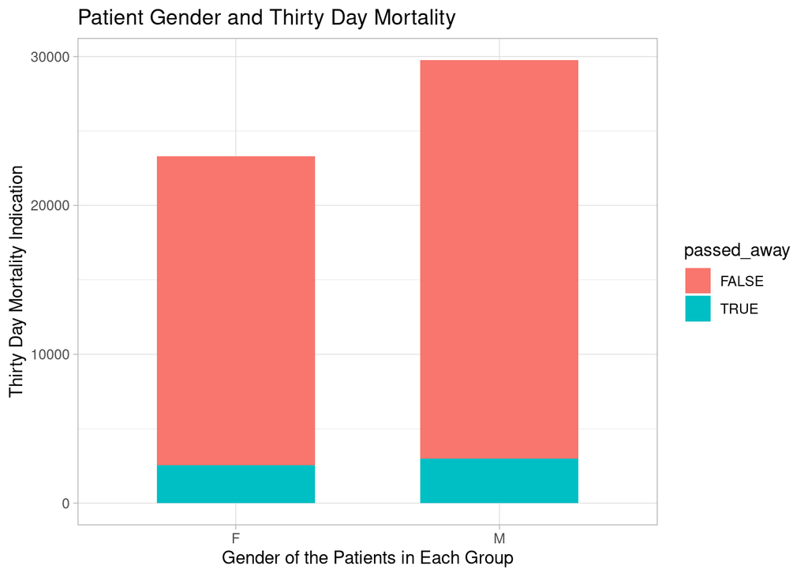

```r
mimic_icu_cohort %>%
  mutate(passed_away = (mimic_icu_cohort$thirty_day_mort == T)) %>%
  ggplot(aes(x = gender, fill = passed_away)) +
  geom_bar(position = "stack", width = 0.6) +
  ggtitle("Patient Gender and Thirty Day Mortality") +
  xlab("Gender of the Patients in Each Group") +
  ylab("Thirty Day Mortality Indication") +
  theme(aspect.ratio = 1/2) +
  theme_light()
```

```r
mimic_icu_cohort %>%
  count(gender, thirty_day_mort) %>%
  spread(thirty_day_mort, n)
```

```
## # A tibble: 2 × 3
##   gender `FALSE` `TRUE`
##   <chr>    <int>  <int>
## 1 F        20779   2542
## 2 M        26779   2981
```

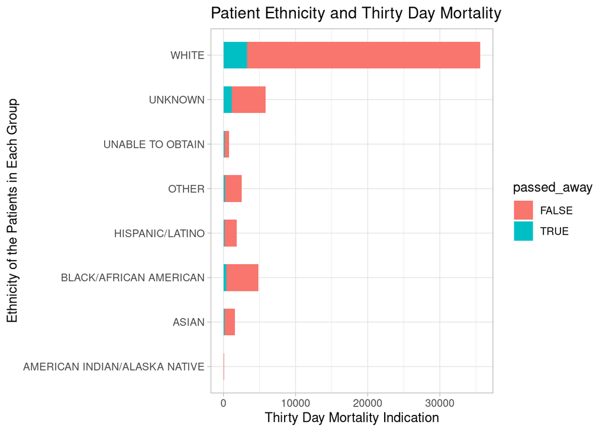

```r
mimic_icu_cohort %>%
  mutate(passed_away = (mimic_icu_cohort$thirty_day_mort == T)) %>%
  ggplot(aes(x = ethnicity, fill = passed_away)) +
  geom_bar(position = "stack", width = 0.6) +
  ggtitle("Patient Ethnicity and Thirty Day Mortality") +
  xlab("Ethnicity of the Patients in Each Group") +  #NEED ABBREVIATIONS
  ylab("Thirty Day Mortality Indication") +
  theme(aspect.ratio = 1/2) +
  theme_light() +
  coord_flip()
```

```r
mimic_icu_cohort %>%
  count(ethnicity, thirty_day_mort) %>%
  spread(thirty_day_mort, n)
```

```
## # A tibble: 8 × 3
##   ethnicity                     `FALSE` `TRUE`
##   <chr>                           <int>  <int>
## 1 AMERICAN INDIAN/ALASKA NATIVE      86      8
## 2 ASIAN                            1391    173
## 3 BLACK/AFRICAN AMERICAN           4462    408
## 4 HISPANIC/LATINO                  1701    122
## 5 OTHER                            2312    223
## 6 UNABLE TO OBTAIN                  630    127
## 7 UNKNOWN                          4657   1161
## 8 WHITE                           32319   3301
```

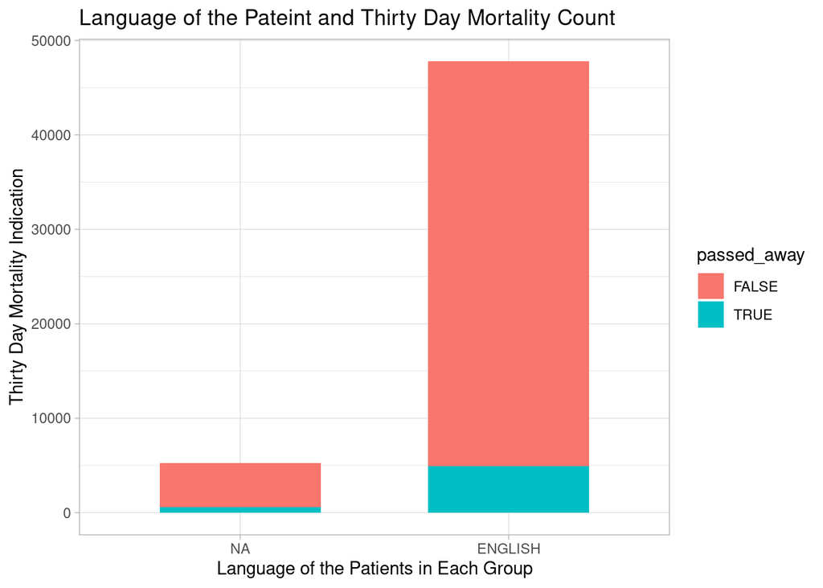

```r
mimic_icu_cohort %>%
  mutate(passed_away = (mimic_icu_cohort$thirty_day_mort == T)) %>%
  ggplot(aes(x = language, fill = passed_away)) +
  geom_bar(position = "stack", width = 0.6) +
  scale_x_discrete(labels = c("NA", "ENGLISH")) +
  ggtitle("Language of the Pateint and Thirty Day Mortality Count") +
  xlab("Language of the Patients in Each Group") +
  ylab("Thirty Day Mortality Indication") +
  theme(aspect.ratio = 1/2) +
  theme_light()
```

```r
mimic_icu_cohort %>%
  mutate(language = if_else(language=="?","NA", language)) %>%
  count(language, thirty_day_mort) %>%
  spread(thirty_day_mort, n)
```

```
## # A tibble: 2 × 3
##   language `FALSE` `TRUE`
##   <chr>      <int>  <int>
## 1 ENGLISH    42866   4929
## 2 NA          4692    594
```

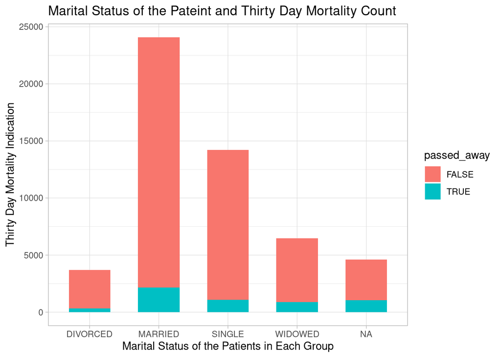

```r
mimic_icu_cohort %>%
  mutate(passed_away = (mimic_icu_cohort$thirty_day_mort == T)) %>%
  ggplot(aes(x = marital_status, fill = passed_away)) +
  geom_bar(position = "stack", width = 0.6) +
  ggtitle("Marital Status of the Pateint and Thirty Day Mortality Count") +
  xlab("Marital Status of the Patients in Each Group") +
  ylab("Thirty Day Mortality Indication") +
  theme(aspect.ratio = 1/2) +
  theme_light()
```

```r
mimic_icu_cohort %>%
  count(marital_status, thirty_day_mort) %>%
  spread(thirty_day_mort, n)
```

```
## # A tibble: 5 × 3
##   marital_status `FALSE` `TRUE`
##   <chr>            <int>  <int>
## 1 DIVORCED          3373    320
## 2 MARRIED          21903   2175
## 3 SINGLE           13142   1081
## 4 WIDOWED           5565    898
## 5 <NA>              3575   1049
```

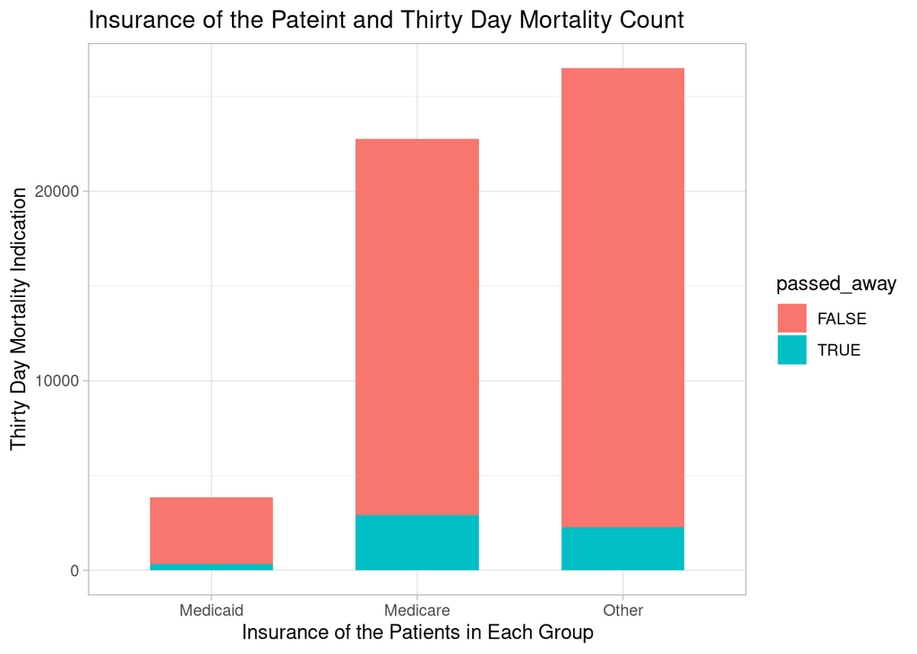

```r
mimic_icu_cohort %>%
  mutate(passed_away = (mimic_icu_cohort$thirty_day_mort == T)) %>%
  ggplot(aes(x = insurance, fill = passed_away)) +
  geom_bar(position = "stack", width = 0.6) +
  ggtitle("Insurance of the Pateint and Thirty Day Mortality Count") +
  xlab("Insurance of the Patients in Each Group") +
  ylab("Thirty Day Mortality Indication") +
  theme(aspect.ratio = 1/2) +
  theme_light()
```

```r
mimic_icu_cohort %>%
  count(insurance, thirty_day_mort) %>%
  spread(thirty_day_mort, n)
```

```
## # A tibble: 3 × 3
##   insurance `FALSE` `TRUE`
##   <chr>       <int>  <int>
## 1 Medicaid     3515    321
## 2 Medicare    19828   2918
## 3 Other       24215   2284
```

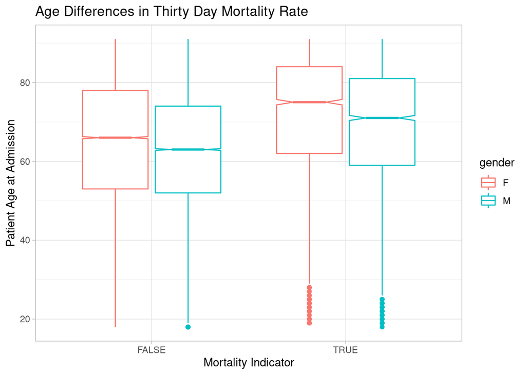

```r
mimic_icu_cohort %>%
  group_by(thirty_day_mort) %>%
  ggplot(aes(x = thirty_day_mort, y = anchor_age, color = gender)) +
  geom_boxplot(notch = T) +
  ggtitle("Age Differences in Thirty Day Mortality Rate") +
  xlab("Mortality Indicator") +
  ylab("Patient Age at Admission") +
  theme_light()
```

```r
age_vs_mortality <- mimic_icu_cohort %>%
  group_by(thirty_day_mort) %>%
  summarise(
    means = mean(anchor_age),
    sd = sd(anchor_age)
    )
age_vs_mortality
```

```
## # A tibble: 2 × 3
##   thirty_day_mort means    sd
##   <lgl>           <dbl> <dbl>
## 1 FALSE            62.7  17.3
## 2 TRUE             70.2  15.5
```

- `thirty_day_mort` vs first lab measurements.

```
## notch went outside hinges. Try setting notch=FALSE.
## notch went outside hinges. Try setting notch=FALSE.
```

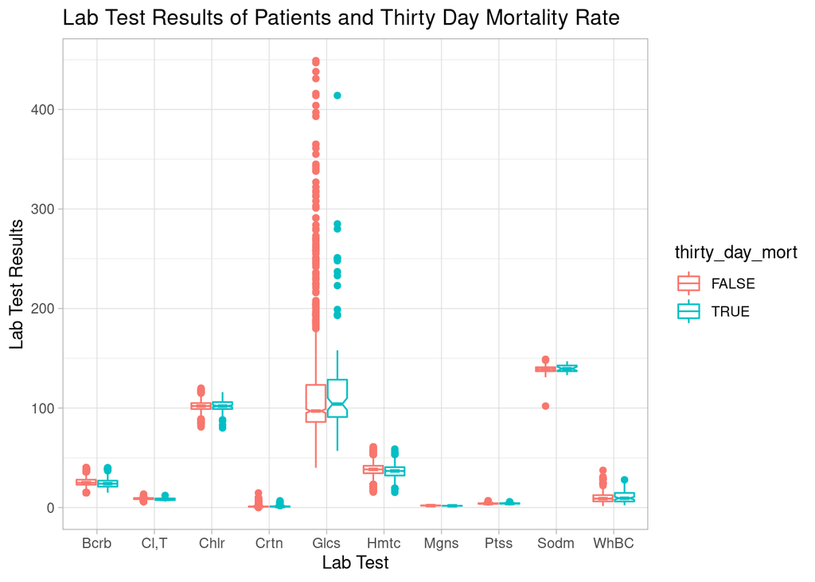

```r
mimic_icu_cohort %>%
  ggplot(aes(x = lab_test_name, y = lab_test_result, color = thirty_day_mort)) +
  geom_boxplot(notch = T) +
  ggtitle("Lab Test Results of Patients and Thirty Day Mortality Rate") +
  scale_x_discrete(labels = abbreviate) +
  xlab("Lab Test") +
  ylab("Lab Test Results") +
  theme_light()
```

```r
mimic_icu_cohort %>%
  ungroup() %>%
  select(stay_id, lab_test_id, lab_test_result, thirty_day_mort) %>%
  pivot_wider(names_from = lab_test_id, values_from = lab_test_result) %>%
  group_by(thirty_day_mort) %>%
  summarise(
    bicarbonate = format(mean(na.omit(`50882`)), digits = 3),
    calcium = format(mean(na.omit(`50893`)), digits = 3),
    chloride = format(mean(na.omit(`50902`)), digits = 3),
    creatinine = format(mean(na.omit(`50912`)), digits = 3),
    glucose = format(mean(na.omit(`50931`)), digits = 3),
    hematocrit = format(mean(na.omit(`51221`)), digits = 3),
    magnesium = format(mean(na.omit(`50960`)), digits = 3),
    potassium = format(mean(na.omit(`50971`)), digits = 3),
    sodium = format(mean(na.omit(`50983`)), digits = 3),
    WBC_count = format(mean(na.omit(`51301`)), digits = 3)
    ) %>%
  print(width = Inf)
```

```
## # A tibble: 2 × 11
##   thirty_day_mort bicarbonate calcium chloride creatinine glucose hematocrit
##   <lgl>           <chr>       <chr>   <chr>    <chr>      <chr>   <chr>
## 1 FALSE           25.1        8.96    102      1.08       117     38.1
## 2 TRUE            24.2        8.34    102      1.23       122     36.5
##   magnesium potassium sodium WBC_count
##   <chr>     <chr>     <chr>  <chr>
## 1 2.02      4.14      139    10.1
## 2 1.8       4.19      140    11
```

- `thirty_day_mort` vs first vital measurements

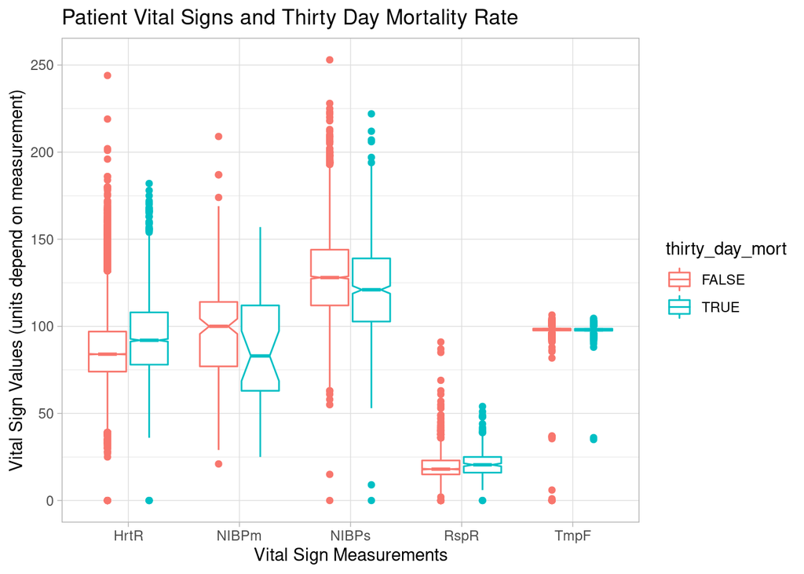

```r
mimic_icu_cohort %>%
  ggplot(aes(x = vitals_test_name, y = vitals_test_result, color = thirty_day_mort)) +
  geom_boxplot(notch = T) +
  scale_x_discrete(labels = abbreviate) +
  ggtitle("Patient Vital Signs and Thirty Day Mortality Rate") +
  xlab("Vital Sign Measurements") +
  ylab("Vital Sign Values (units depend on measurement)") +
  theme_light()
```

```r
mimic_icu_cohort %>%
  ungroup() %>%
  select(stay_id, vitals_test_id, vitals_test_result, thirty_day_mort) %>%
  pivot_wider(names_from = vitals_test_id, values_from = vitals_test_result) %>%
  group_by(thirty_day_mort) %>%
  summarise(
    heart_rate = format(mean(na.omit(`220045`)), digits = 3),
    mean_blood_pressure = format(mean(na.omit(`220181`)), digits = 3),
    blood_pressure_systolic = format(mean(na.omit(`220179`)), digits = 3),
    temperature = format(mean(na.omit(`223761`)), digits = 3),
    respiratory_rate = format(mean(na.omit(`220210`)), digits = 3)
    ) %>%
  print(width = Inf)
```

```
## # A tibble: 2 × 6
##   thirty_day_mort heart_rate mean_blood_pressure blood_pressure_systolic
##   <lgl>           <chr>      <chr>               <chr>
## 1 FALSE           86.6       97.6                129
## 2 TRUE            93.2       86.1                122
##   temperature respiratory_rate
##   <chr>       <chr>
## 1 98.1        19.7
## 2 97.9        21.3
```

- `thirty_day_mort` vs first ICU unit

[figure not shown]

```r
mimic_icu_cohort %>%
  ggplot(aes(x = first_careunit, fill = thirty_day_mort)) +
  geom_bar(position = "stack", width = 0.6) +
  scale_x_discrete(labels = abbreviate) +
  ggtitle("First Care Unit of Admittance and Thirty Day Mortality Count") +
  xlab("Number of Patients in Each Survival Category") +
  ylab("First Care Unit") +
  theme_light() +
  coord_flip()
```